### **Group Members**

#### Gopal L Godhani 2659618

## PCA Analysis and Multiple Linear Regression on Boston Housing Data

_______________________________________________________________________________________________________________________________________________________

### Introduction to PCA and linear regression

- PCA

  [Principal Component Analysis](https://en.wikipedia.org/wiki/Principal_component_analysis) or PCA of data is essentially a sequence of *p* unit vectors, where the *i<sup>th</sup>* vector is the direction of a line that best fits the data while being orthogonal to the first *i − 1* vectors. It is usually used as a dimension-reduction method when dealing with large datasets while still keeping the variance as intact as possible from the original data. This dimension reduction typically comes at an expense of reduction in the model accuracy. Overall, PCA is a mathematical method that takes linearly correlated features and returns a small uncorrelated features. It’s often used in dimensionality reduction to simplify learning models or to convert multidimensional data into 2D or 3D data that’s easier to see.
- Linear Regression

  To predict the relationship (line) between data points. It is dependent on the intercept and slope in the linear model. We must first decide whether there is a relationship between the variables of interest before using the linear regression model. The correlation coefficient is a useful indicator of how closely two variables are related. It value ranges from -1 (bad relationship) to 1 (strong relationship)

### Basic Flow Chart

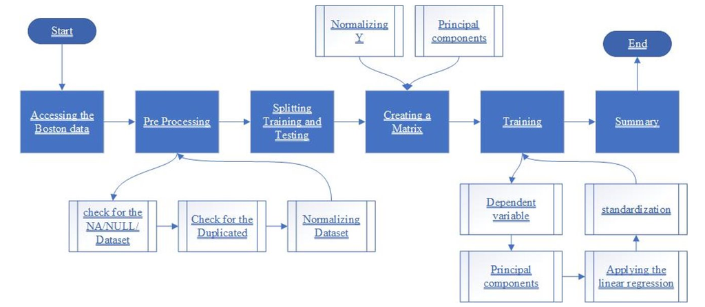

Flow Chart

### Data Analysis and processing

- Housing data for 506 census tracts of Boston from the 1970 census. The dataframe BostonHousing contains the original data by Harrison and Rubinfeld (1979), the dataframe BostonHousing2 the corrected version with additional spatial information (see references below).

#### Data Format

→ The original data are 506 observations on 14 variables, medv being the target variable

Following are the [variables](https://stat.ethz.ch/R-manual/R-devel/library/MASS/html/Boston.html) in the data.

```r
# crim - per capita crime rate by town
# zn - proportion of residential land zoned for lots over 25,000 sq.ft
# indus - proportion of non-retail business acres per town
# chas - Charles River dummy variable (= 1 if tract bounds river; 0 otherwise)
# nox - nitric oxides concentration (parts per 10 million)
# rm -  average number of rooms per dwelling
# age - proportion of owner-occupied units built prior to 1940
# dis - weighted distances to five Boston employment centres
# rad - index of accessibility to radial highways
# tax - full-value property-tax rate per USD 10,000
# ptratio - pupil-teacher ratio by town
# b - 1000(B - 0.63)^2 where B is the proportion of blacks by town
# lstat - percentage of lower status of the population
# medv - median value of owner-occupied homes in USD 1000's
```

#### ‣ Loading and loading the required libraries

```r
#install.packages("MASS")
#install.packages("dplyr")
#install.packages("ggplot2")
#install.packages("corrplot")
#install.packages("tidyverse")
#install.packages("clusterSim")
#install.packages("glmnet")
#install.packages("factoextra")
#install.packages("ggfortify")
```

#### ‣ Loading the required packages

```r
library(MASS)
library(dplyr)
library(ggplot2)
library(corrplot)
library(tidyverse)
library(clusterSim)
library(glmnet)
library(factoextra)
library(ggfortify)
```

#### ‣ Collecting data

→ For this analysis, we are using, “Botson” a dataset representing a random sample of 506 and 14 variables.

- Data source: The original data have been taken from the [UCI Repository Of Machine Learning Databases](http://www.ics.uci.edu/~mlearn/MLRepository.html).

→ Data can be accessed by loading package [MASS](https://cran.r-project.org/web/packages/MASS/MASS.pdf).

```r
#Load data in a frame
df_Boston <- Boston
```

#### ‣ Explore and Analyze the data

```r
#check dimention
dim(df_Boston)
```

```
## [1] 506  14
```

```r
#check head and tail
head(df_Boston)
```

|  | crim | zn | indus | chas | nox | rm | age | dis | rad | tax | ptratio | black | lstat | medv |
| --- | --- | --- | --- | --- | --- | --- | --- | --- | --- | --- | --- | --- | --- | --- |
| 1 | 0.00632 | 18 | 2.31 | 0 | 0.538 | 6.575 | 65.2 | 4.0900 | 1 | 296 | 15.3 | 396.90 | 4.98 | 24.0 |
| 2 | 0.02731 | 0 | 7.07 | 0 | 0.469 | 6.421 | 78.9 | 4.9671 | 2 | 242 | 17.8 | 396.90 | 9.14 | 21.6 |
| 3 | 0.02729 | 0 | 7.07 | 0 | 0.469 | 7.185 | 61.1 | 4.9671 | 2 | 242 | 17.8 | 392.83 | 4.03 | 34.7 |
| 4 | 0.03237 | 0 | 2.18 | 0 | 0.458 | 6.998 | 45.8 | 6.0622 | 3 | 222 | 18.7 | 394.63 | 2.94 | 33.4 |
| 5 | 0.06905 | 0 | 2.18 | 0 | 0.458 | 7.147 | 54.2 | 6.0622 | 3 | 222 | 18.7 | 396.90 | 5.33 | 36.2 |
| 6 | 0.02985 | 0 | 2.18 | 0 | 0.458 | 6.430 | 58.7 | 6.0622 | 3 | 222 | 18.7 | 394.12 | 5.21 | 28.7 |

```r
tail(df_Boston)
```

|  | crim | zn | indus | chas | nox | rm | age | dis | rad | tax | ptratio | black | lstat | medv |
| --- | --- | --- | --- | --- | --- | --- | --- | --- | --- | --- | --- | --- | --- | --- |
| 501 | 0.22438 | 0 | 9.69 | 0 | 0.585 | 6.027 | 79.7 | 2.4982 | 6 | 391 | 19.2 | 396.90 | 14.33 | 16.8 |
| 502 | 0.06263 | 0 | 11.93 | 0 | 0.573 | 6.593 | 69.1 | 2.4786 | 1 | 273 | 21.0 | 391.99 | 9.67 | 22.4 |
| 503 | 0.04527 | 0 | 11.93 | 0 | 0.573 | 6.120 | 76.7 | 2.2875 | 1 | 273 | 21.0 | 396.90 | 9.08 | 20.6 |
| 504 | 0.06076 | 0 | 11.93 | 0 | 0.573 | 6.976 | 91.0 | 2.1675 | 1 | 273 | 21.0 | 396.90 | 5.64 | 23.9 |
| 505 | 0.10959 | 0 | 11.93 | 0 | 0.573 | 6.794 | 89.3 | 2.3889 | 1 | 273 | 21.0 | 393.45 | 6.48 | 22.0 |
| 506 | 0.04741 | 0 | 11.93 | 0 | 0.573 | 6.030 | 80.8 | 2.5050 | 1 | 273 | 21.0 | 396.90 | 7.88 | 11.9 |

```r
# structure of the data
str(df_Boston)
```

```
## 'data.frame':    506 obs. of  14 variables:
##  $ crim   : num  0.00632 0.02731 0.02729 0.03237 0.06905 ...
##  $ zn     : num  18 0 0 0 0 0 12.5 12.5 12.5 12.5 ...
##  $ indus  : num  2.31 7.07 7.07 2.18 2.18 2.18 7.87 7.87 7.87 7.87 ...
##  $ chas   : int  0 0 0 0 0 0 0 0 0 0 ...
##  $ nox    : num  0.538 0.469 0.469 0.458 0.458 0.458 0.524 0.524 0.524 0.524 ...
##  $ rm     : num  6.58 6.42 7.18 7 7.15 ...
##  $ age    : num  65.2 78.9 61.1 45.8 54.2 58.7 66.6 96.1 100 85.9 ...
##  $ dis    : num  4.09 4.97 4.97 6.06 6.06 ...
##  $ rad    : int  1 2 2 3 3 3 5 5 5 5 ...
##  $ tax    : num  296 242 242 222 222 222 311 311 311 311 ...
##  $ ptratio: num  15.3 17.8 17.8 18.7 18.7 18.7 15.2 15.2 15.2 15.2 ...
##  $ black  : num  397 397 393 395 397 ...
##  $ lstat  : num  4.98 9.14 4.03 2.94 5.33 ...
##  $ medv   : num  24 21.6 34.7 33.4 36.2 28.7 22.9 27.1 16.5 18.9 ...
```

```r
#summary statistics
summary(df_Boston)
```

```
##       crim                zn             indus            chas
##  Min.   : 0.00632   Min.   :  0.00   Min.   : 0.46   Min.   :0.00000
##  1st Qu.: 0.08204   1st Qu.:  0.00   1st Qu.: 5.19   1st Qu.:0.00000
##  Median : 0.25651   Median :  0.00   Median : 9.69   Median :0.00000
##  Mean   : 3.61352   Mean   : 11.36   Mean   :11.14   Mean   :0.06917
##  3rd Qu.: 3.67708   3rd Qu.: 12.50   3rd Qu.:18.10   3rd Qu.:0.00000
##  Max.   :88.97620   Max.   :100.00   Max.   :27.74   Max.   :1.00000
##       nox               rm             age              dis
##  Min.   :0.3850   Min.   :3.561   Min.   :  2.90   Min.   : 1.130
##  1st Qu.:0.4490   1st Qu.:5.886   1st Qu.: 45.02   1st Qu.: 2.100
##  Median :0.5380   Median :6.208   Median : 77.50   Median : 3.207
##  Mean   :0.5547   Mean   :6.285   Mean   : 68.57   Mean   : 3.795
##  3rd Qu.:0.6240   3rd Qu.:6.623   3rd Qu.: 94.08   3rd Qu.: 5.188
##  Max.   :0.8710   Max.   :8.780   Max.   :100.00   Max.   :12.127
##       rad              tax           ptratio          black
##  Min.   : 1.000   Min.   :187.0   Min.   :12.60   Min.   :  0.32
##  1st Qu.: 4.000   1st Qu.:279.0   1st Qu.:17.40   1st Qu.:375.38
##  Median : 5.000   Median :330.0   Median :19.05   Median :391.44
##  Mean   : 9.549   Mean   :408.2   Mean   :18.46   Mean   :356.67
##  3rd Qu.:24.000   3rd Qu.:666.0   3rd Qu.:20.20   3rd Qu.:396.23
##  Max.   :24.000   Max.   :711.0   Max.   :22.00   Max.   :396.90
##      lstat            medv
##  Min.   : 1.73   Min.   : 5.00
##  1st Qu.: 6.95   1st Qu.:17.02
##  Median :11.36   Median :21.20
##  Mean   :12.65   Mean   :22.53
##  3rd Qu.:16.95   3rd Qu.:25.00
##  Max.   :37.97   Max.   :50.00
```

```r
# check for the NA/NULL values in data.
colSums(is.na(df_Boston))
```

```
##    crim      zn   indus    chas     nox      rm     age     dis     rad     tax
##       0       0       0       0       0       0       0       0       0       0
## ptratio   black   lstat    medv
##       0       0       0       0
```

```r
#Check for duplicated values
sum(duplicated(df_Boston))
```

```
## [1] 0
```

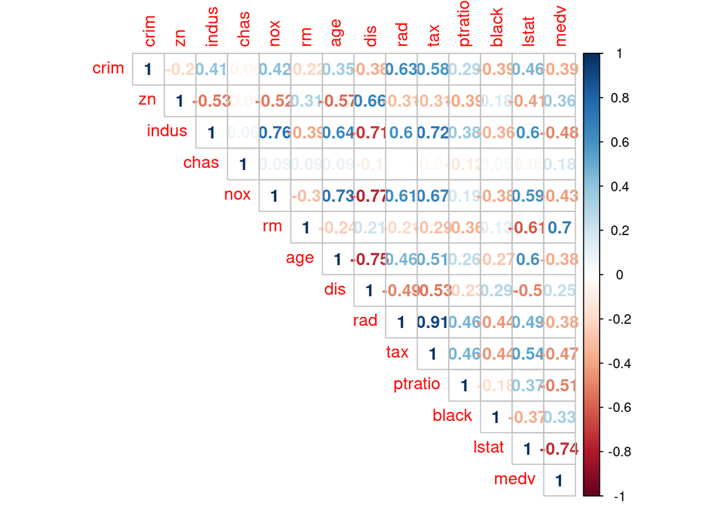

```r
#checking the correlation between features
result_cor<-cor(df_Boston)
corrplot(result_cor,method = "number",type = "upper")
```

**→ Using the correlation matrix, we can derive following observations:**

- The median value of owner-occupied homes in USD 1000’s increases as average number of rooms per dwelling increases.
- The median value of owner-occupied homes in USD 1000’s decreases if percent of lower status population in the area increases.
- Index of accessibility to radial highways increases, full-value property-tax rate per USD 10,000 also goes up.
- Per-capita crime rate by town is also strongly positively related to Index of accessibility to radial highways and full-value property-tax rate per USD 10,000.
- As proportion of non-retail business acres per town increases, the level of nitric oxides concentration (parts per 10 million) goes up.

→ We can notice that some of our predictor variables are highly correlated. Since there are more than two predictor variables present with correlation between then, this suggest we have issue of multicollinearity.

→ Multicollinearity can be a problem as it can undermine the statistical importance of the individual independent variable. Moreover, it can make our model unstable. Moreover, we don’t have in depth details of how each variable behaves in accordance with other, i.e. we have an imprecise estimate of the effect of independent changes.

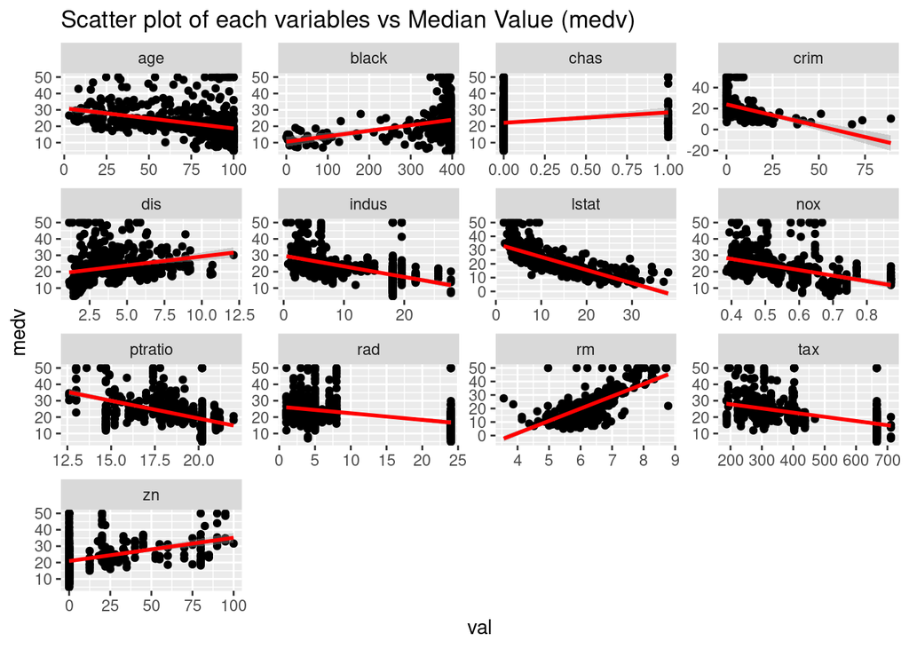

```r
#visualize each predictor variable against medv
df_Boston %>%
  gather(key, val, -medv) %>%
  ggplot(aes(x = val, y = medv)) +
  geom_point() +
  stat_smooth(formula = y ~ x,method = "lm", se = TRUE, col = "red") +
  facet_wrap(~key, scales = "free") +
  theme_gray() +
  ggtitle("Scatter plot of each variables vs Median Value (medv)")
```

→ As we can see, the proportion of the dwellings occupied bu owners prior to 1940 and the proportion of blacks by town is heavily skewed ro the left, at the same time, the crim rate and weighted mean of dis (weighted distances to five Boston employment centers) is mainly skewed to the right.

#### ‣ Normalizing the data

→ The scale of the features in the dataset is very different. However, we need to scale our data before you use it to proceed furthure to calculate PCA and for linear regression. This will help our model to not vary as much.

```r
#z-score normalization
#type n1 - standardization - ((x-mean)/sd).
df_boston_norm_all<-data.Normalization(df_Boston, type = "n1", normalization = "column")
```

```r
#check summary statistics after normalization
summary(df_boston_norm_all)
```

```
##       crim                 zn               indus              chas
##  Min.   :-0.419367   Min.   :-0.48724   Min.   :-1.5563   Min.   :-0.2723
##  1st Qu.:-0.410563   1st Qu.:-0.48724   1st Qu.:-0.8668   1st Qu.:-0.2723
##  Median :-0.390280   Median :-0.48724   Median :-0.2109   Median :-0.2723
##  Mean   : 0.000000   Mean   : 0.00000   Mean   : 0.0000   Mean   : 0.0000
##  3rd Qu.: 0.007389   3rd Qu.: 0.04872   3rd Qu.: 1.0150   3rd Qu.:-0.2723
##  Max.   : 9.924110   Max.   : 3.80047   Max.   : 2.4202   Max.   : 3.6648
##       nox                rm               age               dis
##  Min.   :-1.4644   Min.   :-3.8764   Min.   :-2.3331   Min.   :-1.2658
##  1st Qu.:-0.9121   1st Qu.:-0.5681   1st Qu.:-0.8366   1st Qu.:-0.8049
##  Median :-0.1441   Median :-0.1084   Median : 0.3171   Median :-0.2790
##  Mean   : 0.0000   Mean   : 0.0000   Mean   : 0.0000   Mean   : 0.0000
##  3rd Qu.: 0.5981   3rd Qu.: 0.4823   3rd Qu.: 0.9059   3rd Qu.: 0.6617
##  Max.   : 2.7296   Max.   : 3.5515   Max.   : 1.1164   Max.   : 3.9566
##       rad               tax             ptratio            black
##  Min.   :-0.9819   Min.   :-1.3127   Min.   :-2.7047   Min.   :-3.9033
##  1st Qu.:-0.6373   1st Qu.:-0.7668   1st Qu.:-0.4876   1st Qu.: 0.2049
##  Median :-0.5225   Median :-0.4642   Median : 0.2746   Median : 0.3808
##  Mean   : 0.0000   Mean   : 0.0000   Mean   : 0.0000   Mean   : 0.0000
##  3rd Qu.: 1.6596   3rd Qu.: 1.5294   3rd Qu.: 0.8058   3rd Qu.: 0.4332
##  Max.   : 1.6596   Max.   : 1.7964   Max.   : 1.6372   Max.   : 0.4406
##      lstat              medv
##  Min.   :-1.5296   Min.   :-1.9063
##  1st Qu.:-0.7986   1st Qu.:-0.5989
##  Median :-0.1811   Median :-0.1449
##  Mean   : 0.0000   Mean   : 0.0000
##  3rd Qu.: 0.6024   3rd Qu.: 0.2683
##  Max.   : 3.5453   Max.   : 2.9865
```

→ Now we have mean of 0 and standard devation of 1.

- **Extracting our target variable ‘medv’ so we can use it later**

```r
df_boston_norm_medv <-df_boston_norm_all $medv
```

#### ‣ Computing and using PCA

```r
#PCA
df_Boston_pca <- prcomp(df_boston_norm_all)
```

- **Check for std dev and variance of PCA**

```r
#summary of PCA components
summary(df_Boston_pca)
```

```
## Importance of components:
##                           PC1    PC2     PC3     PC4     PC5     PC6     PC7
## Standard deviation     2.5585 1.2843 1.16142 0.94156 0.92244 0.81241 0.73172
## Proportion of Variance 0.4676 0.1178 0.09635 0.06332 0.06078 0.04714 0.03824
## Cumulative Proportion  0.4676 0.5854 0.68174 0.74507 0.80585 0.85299 0.89123
##                            PC8    PC9    PC10   PC11    PC12    PC13    PC14
## Standard deviation     0.63488 0.5266 0.50225 0.4613 0.42777 0.36607 0.24561
## Proportion of Variance 0.02879 0.0198 0.01802 0.0152 0.01307 0.00957 0.00431
## Cumulative Proportion  0.92003 0.9398 0.95785 0.9730 0.98612 0.99569 1.00000
```

→ As we can see, first seven principal components accounts for ≅ 90% variance of the data. So, we can move forward with using just first seven of all the components to build our linear model.

- **Eigenvalues**

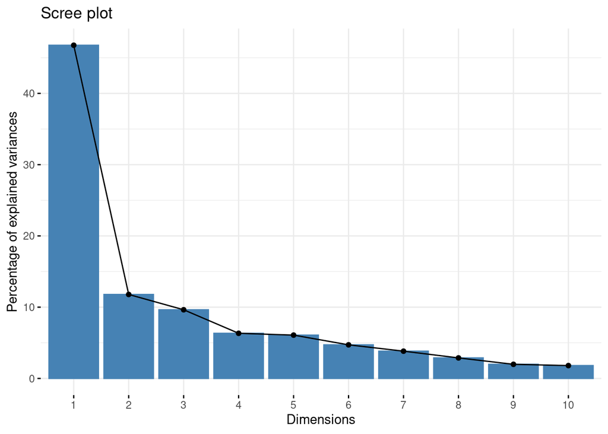

```r
#Visualize eigenvalues (scree plot).
fviz_eig(df_Boston_pca)
```

→ The plot above shows the percentage of variances explained by each principal component computed from our data. PC1 can explain the most variance.

- **Biplot of individuals and variables**

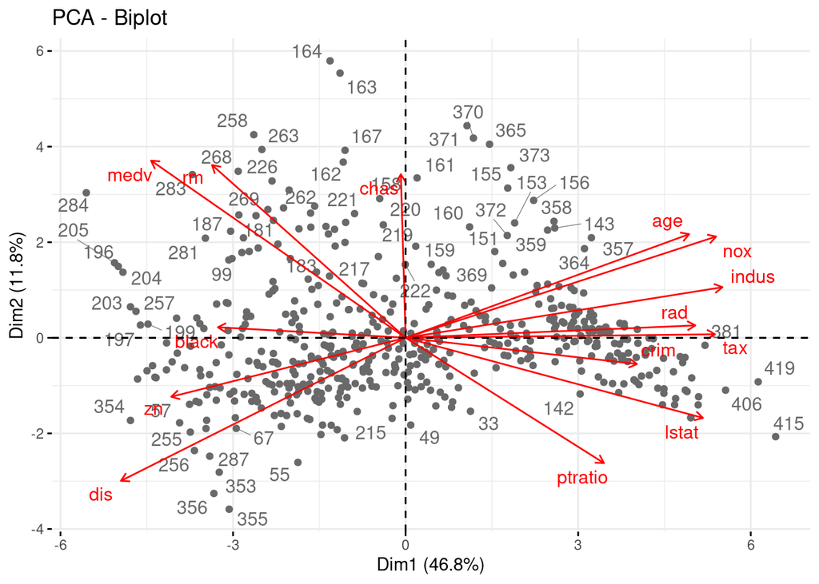

```r
fviz_pca_biplot(df_Boston_pca, repel = TRUE,
                col.var = "red", # Variables color
                col.ind = "#696969"  # Individuals color,
)
```

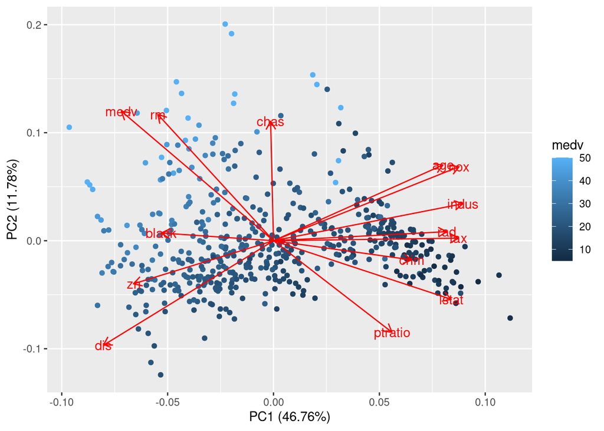

```r
#plotting PCA
autoplot(df_Boston_pca, data=df_Boston,loadings=TRUE,loadings.label=T, colour = 'medv' )
```

- **plot percentage of variance explained by each principal component**

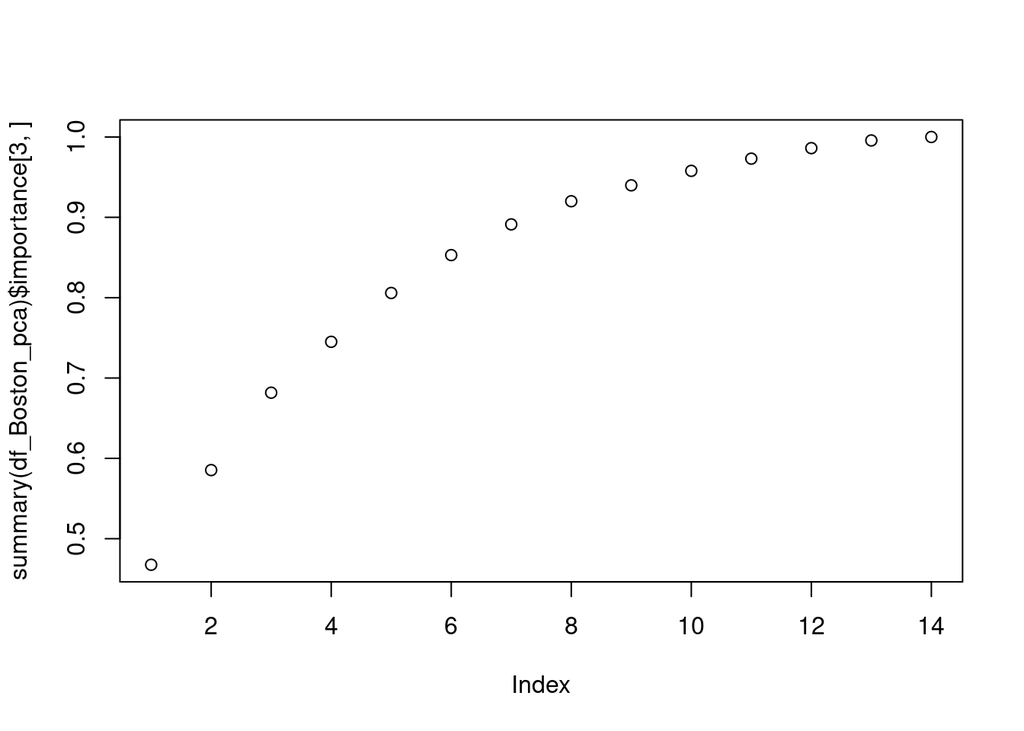

```r
# each PC variance in %
plot(summary(df_Boston_pca)$importance[3,])
```

- **Check how strongly a loading of variable contributes to pricipal components**

→ NOTE: Here, I have only included plots for first eight PCs

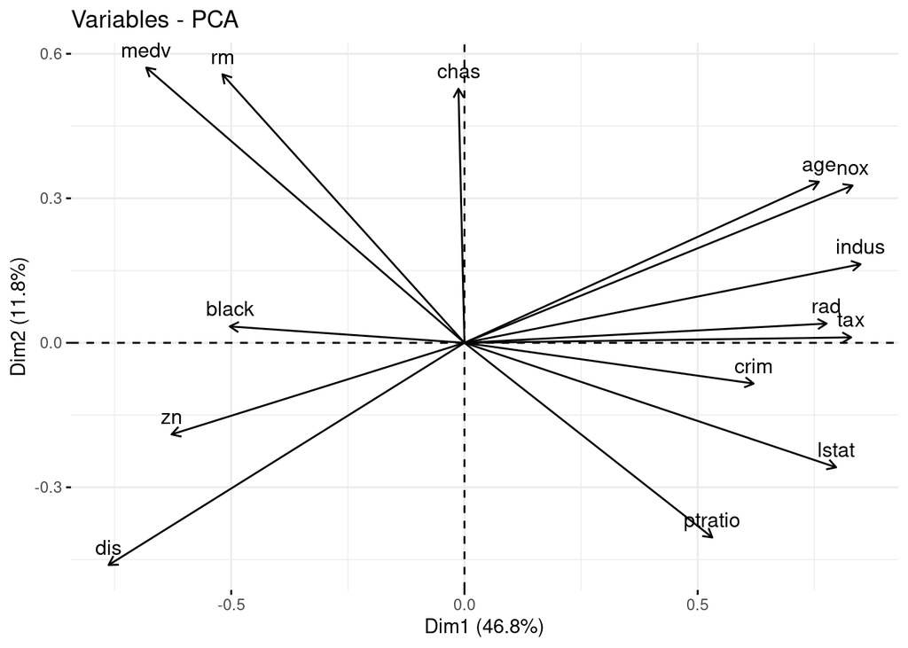

```r
fviz_pca_var(df_Boston_pca,axes = c(1, 2))
```

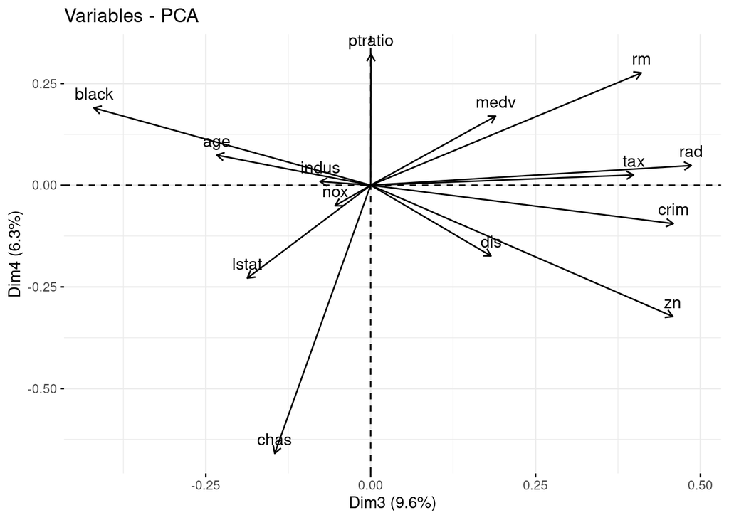

```r
fviz_pca_var(df_Boston_pca,axes = c(3, 4))
```

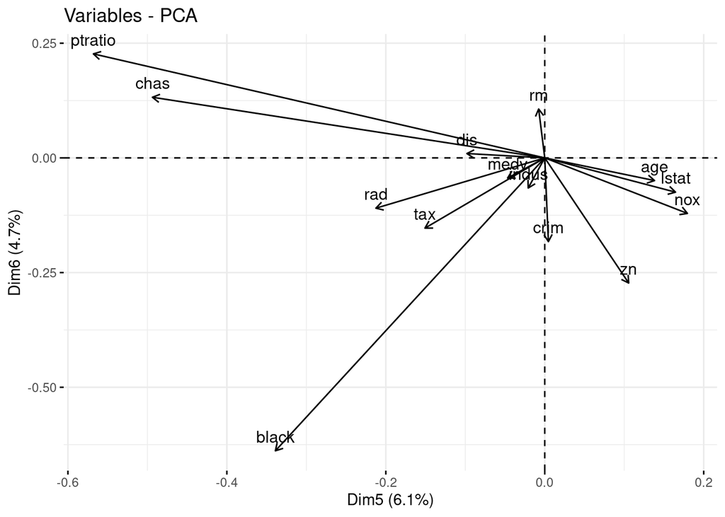

```r
fviz_pca_var(df_Boston_pca,axes = c(5, 6))
```

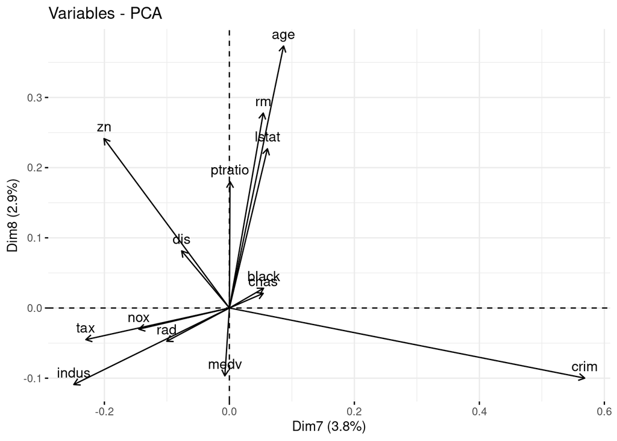

```r
fviz_pca_var(df_Boston_pca,axes = c(7, 8))
```

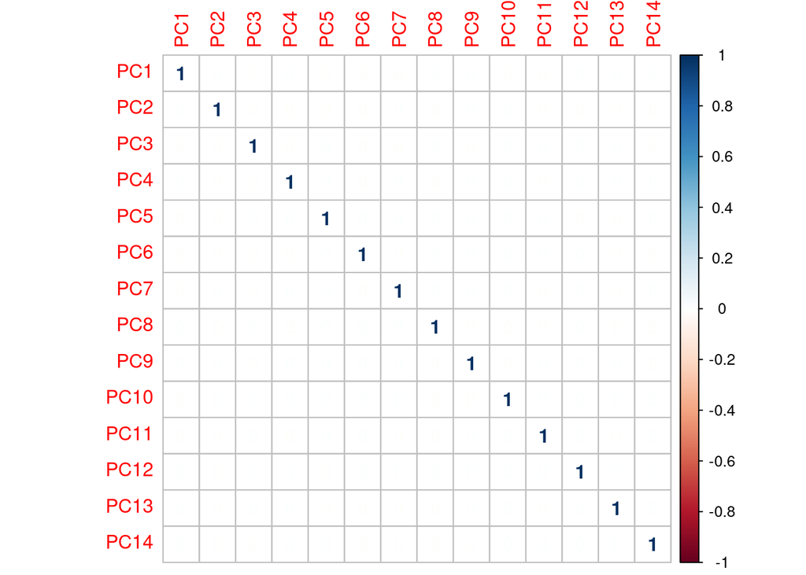

```r
## correlation matrix principal components
cor_pca <- cor(df_Boston_pca$x, method = "pearson")
corrplot(cor_pca, method = "number")
```

→ As we can see from the plot above, there is no correlation between each of the principal component of data.

- **Extracting PC from output**

```r
principal_cps <- as.data.frame(df_Boston_pca$x)
```

- **Creating matrix using first seven PC to feed in our model**

```r
pca7_mv_data <- cbind(df_boston_norm_medv,principal_cps[,1:7])

head(pca7_mv_data)
```

|  | df_boston_norm_medv | PC1 | PC2 | PC3 | PC4 | PC5 | PC6 | PC7 |
| --- | --- | --- | --- | --- | --- | --- | --- | --- |
| 1 | 0.1595278 | -2.085280 | 0.4923660 | -0.33565863 | 0.02806062 | 1.01179950 | -0.2618327 | 0.3275539 |
| 2 | -0.1014239 | -1.372024 | -0.1707548 | -0.96500929 | 0.43197898 | 0.25439282 | 0.3034788 | 0.5585569 |
| 3 | 1.3229375 | -2.374204 | 0.9131235 | -0.08993678 | 1.12280202 | -0.03275573 | 0.5083969 | 0.4870519 |
| 4 | 1.1815886 | -2.834974 | 0.1946773 | 0.06048549 | 1.06462885 | -0.45987914 | 0.7133022 | 0.6227126 |
| 5 | 1.4860323 | -2.770174 | 0.4328708 | 0.06397874 | 1.12852010 | -0.38180095 | 0.6552062 | 0.7038004 |
| 6 | 0.6705582 | -2.298644 | -0.3283548 | -0.44993218 | 0.69305853 | -0.29988892 | 0.5822707 | 0.6480631 |

```r
dim(pca7_mv_data)
```

```
## [1] 506   8
```

- **Scatter plots showing relationship between PCs and our target variable**

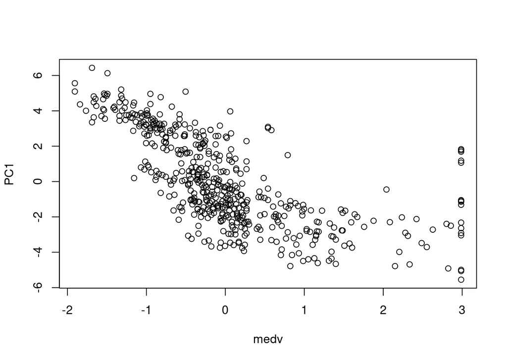

```r
plot(x=df_boston_norm_medv,y=pca7_mv_data$PC1, xlab="medv",ylab="PC1")
```

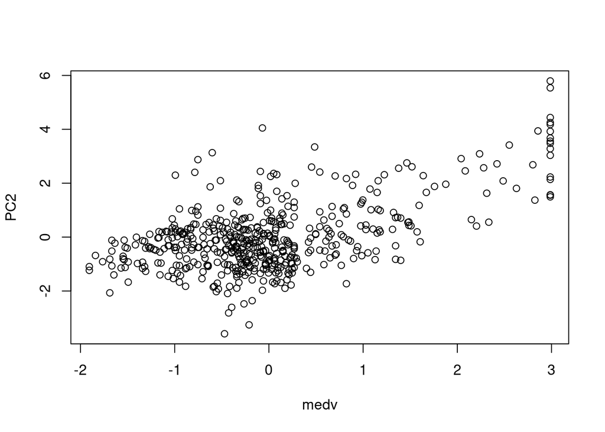

```r
plot(x=df_boston_norm_medv,y=pca7_mv_data$PC2, xlab="medv",ylab="PC2")
```

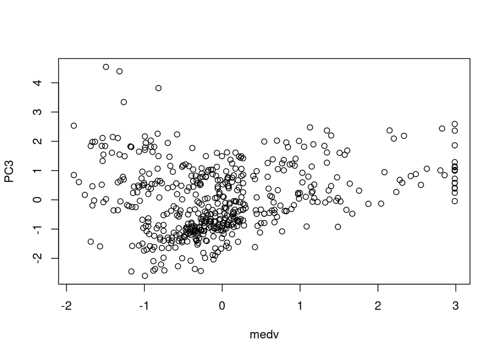

```r
plot(x=df_boston_norm_medv,y=pca7_mv_data$PC3, xlab="medv",ylab="PC3")
```

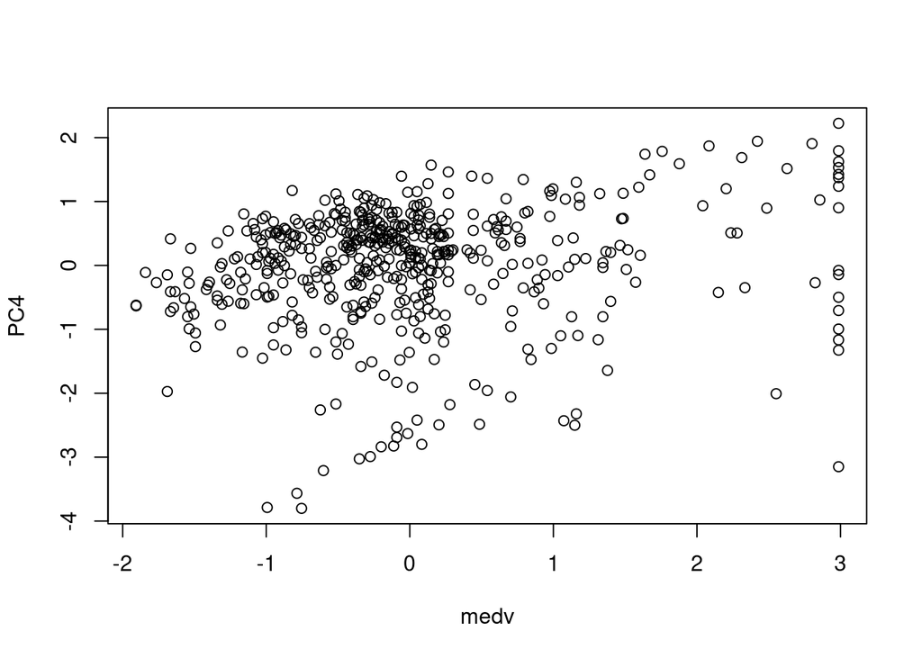

```r
plot(x=df_boston_norm_medv,y=pca7_mv_data$PC4, xlab="medv",ylab="PC4")
```

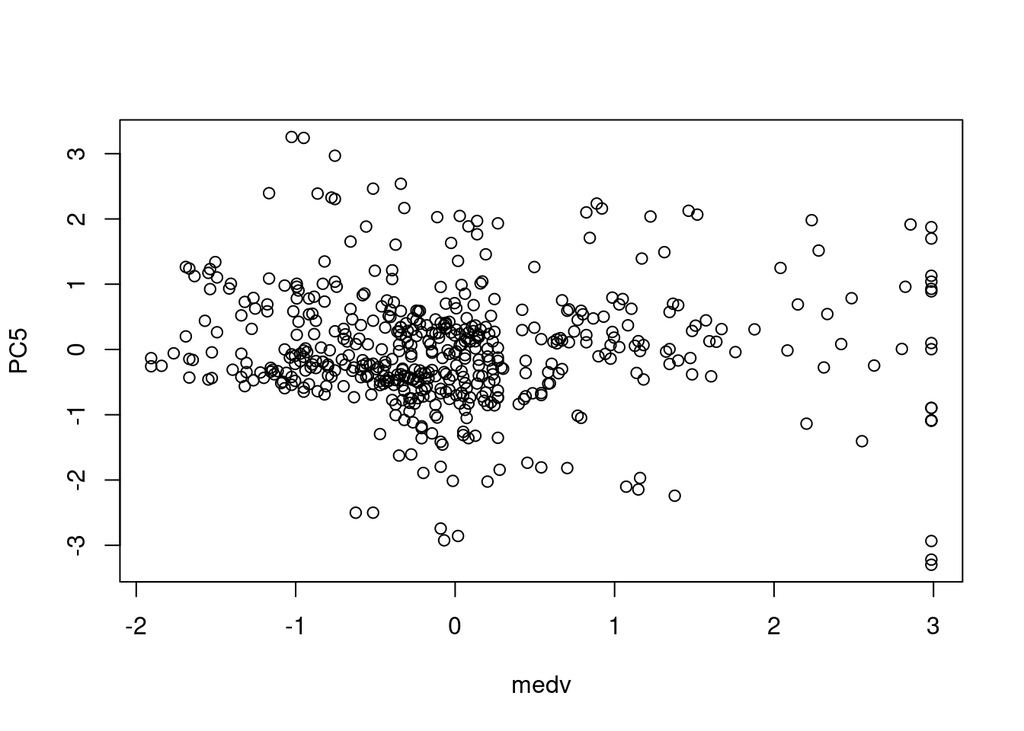

```r
plot(x=df_boston_norm_medv,y=pca7_mv_data$PC5, xlab="medv",ylab="PC5")
```

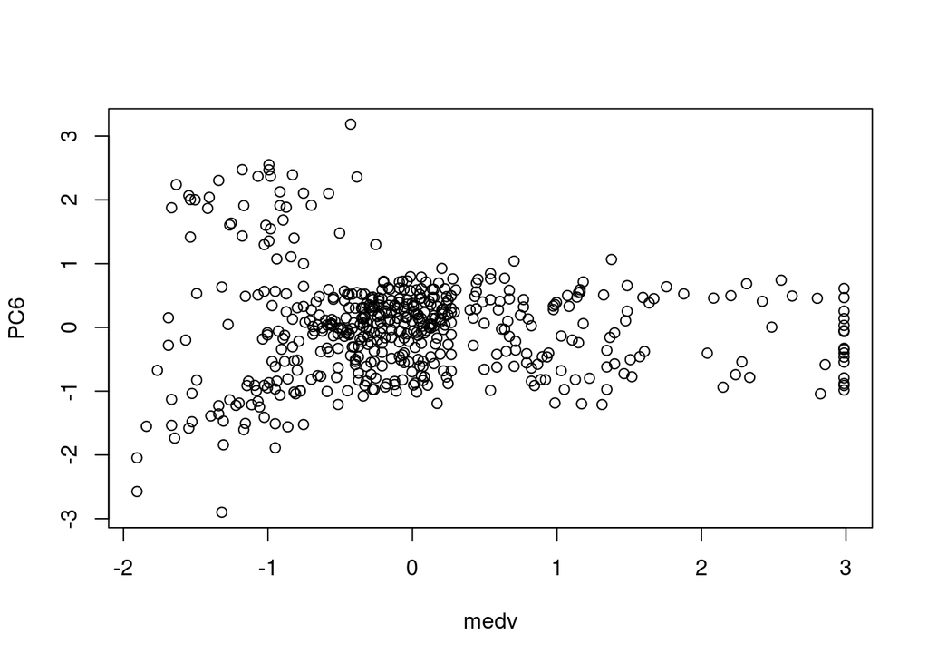

```r
plot(x=df_boston_norm_medv,y=pca7_mv_data$PC6, xlab="medv",ylab="PC6")
```

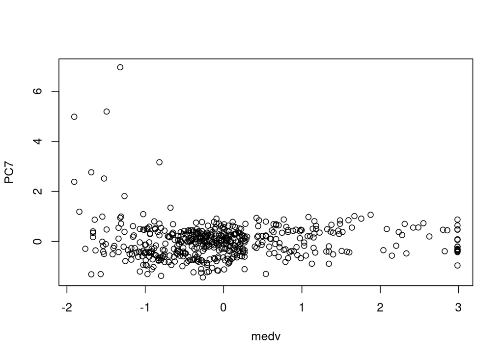

```r
plot(x=df_boston_norm_medv,y=pca7_mv_data$PC7, xlab="medv",ylab="PC7")
```

#### ‣ Data modeling

```r
# split the data
df_Boston_train<-df_boston_norm_all[1:380,]
df_Boston_test<-df_boston_norm_all[381:506,]

df_Boston_train_pca<-pca7_mv_data[1:380,]
df_Boston_test_pca<-pca7_mv_data[381:506,]
```

- **With PCA**

```r
# applying the linear regression to data with PCA
l_model_pca <- lm(df_boston_norm_medv ~ ., data = df_Boston_train_pca)
#check the model
summary(l_model_pca)
```

```
##
## Call:
## lm(formula = df_boston_norm_medv ~ ., data = df_Boston_train_pca)
##
## Residuals:
##      Min       1Q   Median       3Q      Max
## -1.99488 -0.17962 -0.03673  0.14914  1.94534
##
## Coefficients:
##             Estimate Std. Error t value Pr(>|t|)
## (Intercept)  0.04533    0.02812   1.612  0.10783
## PC1         -0.25078    0.01544 -16.238  < 2e-16 ***
## PC2          0.46120    0.01415  32.587  < 2e-16 ***
## PC3          0.17748    0.03121   5.687 2.61e-08 ***
## PC4          0.23775    0.02020  11.770  < 2e-16 ***
## PC5         -0.09557    0.02206  -4.333 1.90e-05 ***
## PC6         -0.11807    0.04010  -2.944  0.00344 **
## PC7         -0.06331    0.05400  -1.172  0.24179
## ---
## Signif. codes:  0 '***' 0.001 '**' 0.01 '*' 0.05 '.' 0.1 ' ' 1
##
## Residual standard error: 0.3614 on 372 degrees of freedom
## Multiple R-squared:  0.8607, Adjusted R-squared:  0.8581
## F-statistic: 328.3 on 7 and 372 DF,  p-value: < 2.2e-16
```

- **Without PCA**

```r
# applying the linear regression to data with PCA
l_model_2 <- lm(medv ~ ., data = df_Boston_train)
summary(l_model_2)
```

```
##
## Call:
## lm(formula = medv ~ ., data = df_Boston_train)
##
## Residuals:
##      Min       1Q   Median       3Q      Max
## -2.53732 -0.27134 -0.06556  0.19069  2.52067
##
## Coefficients:
##              Estimate Std. Error t value Pr(>|t|)
## (Intercept)  0.147148   0.040426   3.640 0.000312 ***
## crim        -0.260306   0.149159  -1.745 0.081796 .
## zn           0.116461   0.035109   3.317 0.001001 **
## indus        0.051258   0.047858   1.071 0.284849
## chas         0.025202   0.024552   1.026 0.305336
## nox         -0.192524   0.056231  -3.424 0.000687 ***
## rm           0.403692   0.037017  10.906  < 2e-16 ***
## age         -0.004433   0.043425  -0.102 0.918741
## dis         -0.301705   0.047838  -6.307 8.22e-10 ***
## rad          0.599978   0.098171   6.112 2.53e-09 ***
## tax         -0.266415   0.079792  -3.339 0.000928 ***
## ptratio     -0.191241   0.032312  -5.919 7.47e-09 ***
## black        0.018619   0.064637   0.288 0.773464
## lstat       -0.353784   0.049943  -7.084 7.24e-12 ***
## ---
## Signif. codes:  0 '***' 0.001 '**' 0.01 '*' 0.05 '.' 0.1 ' ' 1
##
## Residual standard error: 0.5101 on 366 degrees of freedom
## Multiple R-squared:  0.727,  Adjusted R-squared:  0.7173
## F-statistic: 74.97 on 13 and 366 DF,  p-value: < 2.2e-16
```

- **shows which predicotr variable are significant**

```r
#check for coeeficient siginificance
summary(l_model_pca)$coef
```

```
##                Estimate Std. Error    t value      Pr(>|t|)
## (Intercept)  0.04533134 0.02812271   1.611912  1.078291e-01
## PC1         -0.25078441 0.01544424 -16.238058  3.350789e-45
## PC2          0.46119780 0.01415296  32.586667 4.899833e-111
## PC3          0.17748490 0.03120718   5.687310  2.614490e-08
## PC4          0.23774948 0.02019984  11.769871  2.116424e-27
## PC5         -0.09556933 0.02205835  -4.332570  1.898579e-05
## PC6         -0.11806502 0.04010482  -2.943911  3.444392e-03
## PC7         -0.06330784 0.05399898  -1.172390  2.417909e-01
```

```r
summary(l_model_2)$coef
```

```
##                 Estimate Std. Error    t value     Pr(>|t|)
## (Intercept)  0.147147609 0.04042642  3.6398872 3.120066e-04
## crim        -0.260306079 0.14915858 -1.7451633 8.179570e-02
## zn           0.116460564 0.03510946  3.3170706 1.000821e-03
## indus        0.051258469 0.04785781  1.0710575 2.848494e-01
## chas         0.025202333 0.02455180  1.0264965 3.053355e-01
## nox         -0.192523566 0.05623101 -3.4237968 6.874541e-04
## rm           0.403691540 0.03701660 10.9056907 3.619374e-24
## age         -0.004433298 0.04342535 -0.1020901 9.187411e-01
## dis         -0.301705265 0.04783822 -6.3067828 8.217015e-10
## rad          0.599977614 0.09817135  6.1115348 2.527917e-09
## tax         -0.266414754 0.07979170 -3.3388781 9.276175e-04
## ptratio     -0.191240928 0.03231201 -5.9185706 7.472888e-09
## black        0.018619499 0.06463747  0.2880604 7.734635e-01
## lstat       -0.353784324 0.04994282 -7.0837879 7.238125e-12
```

- **predict using the model**

```r
#prediction using both the nodels
pred_medv_pca<-predict(l_model_pca, new.data=df_Boston_test_pca,interval = "prediction" )
pred_medv_noPCA <-predict(l_model_pca, new.data=df_Boston_test,interval = "prediction" )
```

#### ‣ Conclusion

One important thing to be noted here is that, using PCA means we are loosing the explainability as we no longer are using the original data

Another reason of using PCA would be that it allows us to make our original data anonymous with keeping the same information intact in the data.

My future work remains to try out PCA with models other than linear regression and analyse how the is being shaped.